# MOdeling Assingment

Group-5 {April Greenwood, Amiya Ranjan Sahoo, Caleb Call, Rob Sheehy}

March 21, 2026

# 1. Introduction

This file evaluates different models to identify which leads are most likely to advance to the next sales step. The EDA established that manufacturing mode is the strongest predictor, followed by account tier, functional area of the contact, and seniority. Geography and industry showed weaker standalone effects but remain useful interaction features.

There are 3 differnet prections used in this file: Logistic Regression, XGBoost, and Random Forest. Outcomes are compared using AUC, accuracy, pecision, recall and F1

# 2. Import Libraries

```r
library(readr)
library(dplyr)
library(tidyr)
library(stringr)
library(forcats)
library(janitor)
library(lubridate)
library(caret)
library(recipes)
library(rsample)
library(xgboost)
library(randomForest)
library(pROC)
library(yardstick)
library(ggplot2)
library(scales)
library(gridExtra)
library(gt)

theme_set(theme_minimal(base_size = 12))
set.seed(123)
```

# 3. Data Overview

This step includes creating a target variable, cleans misisng values, and extracts seniority from jobs.

```r
# Load data

qal_raw <- read_csv("Mastercontrol QAL Performance.csv") %>%
  clean_names()

cat("Dimensions:", nrow(qal_raw), "rows ×", ncol(qal_raw), "columns\n")
```

```
## Dimensions: 16644 rows × 14 columns
```

```r
#EDA data cleaning

qal <- qal_raw %>%

# Target variable
  mutate(
    progressed = if_else(next_stage_c %in% c("SQL", "SQO", "Won"), 1L, 0L)
  ) %>%

  mutate(
    acct_primary_site_function = replace_na(acct_primary_site_function, "Unknown"),
    acct_manufacturing_model   = replace_na(acct_manufacturing_model,   "Unknown"),
    contact_lead_title         = replace_na(contact_lead_title,         "Unknown")
  ) %>%

  mutate(
    title_lower = tolower(contact_lead_title),
    seniority = case_when(
      str_detect(title_lower, "chief|ceo|cfo|cio|cto|coo|president") ~ "C-Level",
      str_detect(title_lower, "vp|vice president")                   ~ "VP",
      str_detect(title_lower, "director|head")                       ~ "Director",
      str_detect(title_lower, "manager|lead")                        ~ "Manager",
      TRUE                                                            ~ "Other"
    )
  ) %>%

  mutate(
    function_band = case_when(
      str_detect(title_lower, "quality|qa|qc")                    ~ "Quality",
      str_detect(title_lower, "manufactur|production|plant")      ~ "Manufacturing",
      str_detect(title_lower, "operation|ops")                    ~ "Operations",
      str_detect(title_lower, "regulator|compliance")             ~ "Regulatory",
      str_detect(title_lower, "engineer|process")                 ~ "Engineering",
      TRUE                                                         ~ "Other"
    )
  ) %>%

  mutate(
    cohort_month = month(qal_cohort_date, label = TRUE, abbr = TRUE)
  ) %>%

  select(-qal_id, -contact_lead_id, -next_stage_c,
         -contact_lead_title, -title_lower, -qal_cohort_date)

qal <- qal %>%
  mutate(
    progressed             = factor(progressed, levels = c(0, 1),
                                    labels = c("No", "Yes")),
    solution_rollup        = factor(solution_rollup),
    acct_target_industry   = factor(acct_target_industry),
    acct_manufacturing_model = factor(acct_manufacturing_model),
    acct_primary_site_function = factor(acct_primary_site_function),
    acct_tier_rollup       = factor(acct_tier_rollup),
    acct_territory_rollup  = factor(acct_territory_rollup),
    last_tactic_campaign_channel = factor(last_tactic_campaign_channel),
    priority               = factor(priority),
    seniority              = factor(seniority),
    function_band          = factor(function_band),
    cohort_month           = factor(cohort_month)
  )

cat("Target distribution:\n")
```

```
## Target distribution:
```

```r
print(prop.table(table(qal$progressed)))
```

```
##
##        No       Yes
## 0.8204758 0.1795242
```

```r
glimpse(qal)
```

```
## Rows: 16,644
## Columns: 13
## $ acct_primary_site_function   <fct> "Food and beverage", "Surgical instrument…
## $ acct_manufacturing_model     <fct> Consumer Packaged Goods, In-House, Hospit…
## $ acct_target_industry         <fct> Non-Life Science, Medical Device, Blood &…
## $ priority                     <fct> P1 - Webinar Demo, Priority 2, Priority 2…
## $ acct_territory_rollup        <fct> Americas, Americas, EMEA, Americas, Ameri…
## $ acct_tier_rollup             <fct> Medium, Medium, Large, Medium, Medium, Me…
## $ solution                     <chr> "Mx", "Mx", "Qx", "Logbooks", "Qx", "Qx",…
## $ solution_rollup              <fct> Mx, Mx, Qx, Mx, Qx, Qx, Qx, Qx, Qx, Qx, Q…
## $ last_tactic_campaign_channel <fct> Online Ads, SEO, Email, External Demand G…
## $ progressed                   <fct> Yes, Yes, No, No, No, No, Yes, No, No, No…
## $ seniority                    <fct> Manager, Manager, Other, C-Level, Manager…
## $ function_band                <fct> Quality, Quality, Other, Other, Quality, …
## $ cohort_month                 <ord> Jun, Nov, Feb, Apr, Jan, Apr, Sep, Sep, F…
```

# 4. Train / Test Split

Data is split into 70% training and 30% testing

```r
split_obj  <- initial_split(qal, prop = 0.70, strata = "progressed")
train_data <- training(split_obj)
test_data  <- testing(split_obj)

cat(sprintf("Training set : %d rows  (%.1f%%)\n",
            nrow(train_data), 100 * nrow(train_data) / nrow(qal)))
```

```
## Training set : 11650 rows  (70.0%)
```

```r
cat(sprintf("Test set     : %d rows  (%.1f%%)\n",
            nrow(test_data),  100 * nrow(test_data)  / nrow(qal)))
```

```
## Test set     : 4994 rows  (30.0%)
```

```r
# Verify class balance is preserved
cat("\nTrain progression rate:", round(mean(train_data$progressed == "Yes"), 3), "\n")
```

```
##
## Train progression rate: 0.179
```

```r
cat("Test  progression rate:", round(mean(test_data$progressed  == "Yes"), 3), "\n")
```

```
## Test  progression rate: 0.18
```

# 5. Data Preparation

```r
# ── A shared recipe applied to all models ────────────────────────────────────
prep_recipe <- recipe(progressed ~ ., data = train_data) %>%

  # Lump rare factor levels (< 3 % of data) into "Other"
  step_other(all_nominal_predictors(), threshold = 0.03) %>%

  # One-hot encode all categoricals (needed for XGBoost & Logistic)
  step_dummy(all_nominal_predictors(), one_hot = TRUE) %>%

  # Remove zero-variance columns created by dummy encoding
  step_zv(all_predictors()) %>%

  # Normalise numeric columns (none here, but safe to include)
  step_normalize(all_numeric_predictors())

prepped   <- prep(prep_recipe, training = train_data)
train_baked <- bake(prepped, new_data = train_data)
test_baked  <- bake(prepped, new_data = test_data)

cat("Features after pre-processing:", ncol(train_baked) - 1, "\n")
```

```
## Features after pre-processing: 69
```

# 6. Model 1 — Logistic Regression

This is the baseline model. It gives an odds ratio revealing how each variable affects the change of progression

```r
# Fit on training data
logit_fit <- glm(
  progressed ~ .,
  data   = train_baked,
  family = binomial(link = "logit")
)

# Predict probabilities on test set
logit_prob <- predict(logit_fit, newdata = test_baked, type = "response")
logit_class <- factor(if_else(logit_prob >= 0.5, "Yes", "No"),
                      levels = c("No", "Yes"))

# Confusion matrix & basic metrics
cm_logit <- confusionMatrix(logit_class, test_baked$progressed, positive = "Yes")
print(cm_logit)
```

```
## Confusion Matrix and Statistics
##
##           Reference
## Prediction   No  Yes
##        No  3920  624
##        Yes  142  269
##
##                Accuracy : 0.8454
##                  95% CI : (0.835, 0.8554)
##     No Information Rate : 0.8198
##     P-Value [Acc > NIR] : 9.51e-07
##
##                   Kappa : 0.3373
##
##  Mcnemar's Test P-Value : < 2.2e-16
##
##             Sensitivity : 0.30123
##             Specificity : 0.96504
##          Pos Pred Value : 0.65450
##          Neg Pred Value : 0.86268
##              Prevalence : 0.18022
##          Detection Rate : 0.05429
##    Detection Prevalence : 0.08295
##       Balanced Accuracy : 0.63314
##
##        'Positive' Class : Yes
##
```

```r
# AUC
roc_logit <- roc(
  response  = test_baked$progressed,
  predictor = logit_prob,
  levels    = c("No", "Yes")
)
cat(sprintf("\nLogistic Regression AUC: %.4f\n", auc(roc_logit)))
```

```
##
## Logistic Regression AUC: 0.8189
```

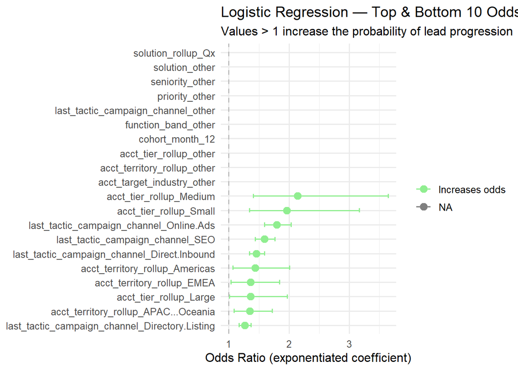

```r
# Top-20 odds ratios (actionable insight)
or_df <- broom::tidy(logit_fit, exponentiate = TRUE, conf.int = TRUE) %>%
  filter(term != "(Intercept)") %>%
  arrange(desc(estimate)) %>%
  slice(c(1:10, (n()-9):n()))   # top 10 & bottom 10

ggplot(or_df, aes(x = reorder(term, estimate),
                  y = estimate,
                  colour = estimate > 1)) +
  geom_point(size = 3) +
  geom_errorbar(aes(ymin = conf.low, ymax = conf.high), width = 0.3) +
  geom_hline(yintercept = 1, linetype = "dashed", colour = "grey") +
  coord_flip() +
  scale_colour_manual(values = c("TRUE" = "lightgreen", "FALSE" = "pink"),
                      labels = c("TRUE" = "Increases odds", "FALSE" = "Decreases odds"),
                      name   = "") +
  labs(
    title    = "Logistic Regression — Top & Bottom 10 Odds Ratios",
    subtitle = "Values > 1 increase the probability of lead progression",
    x = NULL,
    y = "Odds Ratio (exponentiated coefficient)"
  )
```

```r
# Full coefficient table
broom::tidy(logit_fit, exponentiate = TRUE, conf.int = TRUE) %>%
  filter(term != "(Intercept)") %>%
  mutate(across(where(is.numeric), ~ round(.x, 4))) %>%
  arrange(p.value) %>%
  head(30) %>%
  gt() %>%
  tab_header(title = "Logistic Regression: Top 30 Significant Predictors (by p-value)") %>%
  cols_label(
    term      = "Feature",
    estimate  = "Odds Ratio",
    std.error = "Std. Error",
    statistic = "z",
    p.value   = "p-value",
    conf.low  = "95% CI Low",
    conf.high = "95% CI High"
  ) %>%
  tab_style(
    style = cell_fill(color = "lightblue"),
    locations = cells_body(rows = p.value < 0.05)
  )
```

Logistic Regression: Top 30 Significant Predictors (by p-value)

| Feature | Odds Ratio | Std. Error | z | p-value | 95% CI Low | 95% CI High |
| --- | --- | --- | --- | --- | --- | --- |
| acct_manufacturing_model_Not.Enough.Info.Found | 0.6936 | 0.0409 | -8.9511 | 0.0000 | 0.6399 | 0.7511 |
| acct_target_industry_Non.Life.Science | 0.7008 | 0.0743 | -4.7842 | 0.0000 | 0.6067 | 0.8121 |
| priority_No.Priority | 0.8412 | 0.0323 | -5.3560 | 0.0000 | 0.7892 | 0.8958 |
| priority_P1...Video.Demo | 0.7566 | 0.0446 | -6.2500 | 0.0000 | 0.6933 | 0.8258 |
| priority_P1...Webinar.Demo | 0.7163 | 0.0468 | -7.1366 | 0.0000 | 0.6524 | 0.7838 |
| priority_Priority.2 | 0.3026 | 0.0697 | -17.1556 | 0.0000 | 0.2639 | 0.3468 |
| solution_Quality | 1.1999 | 0.0429 | 4.2479 | 0.0000 | 1.1039 | 1.3063 |
| last_tactic_campaign_channel_Direct.Inbound | 1.4605 | 0.0439 | 8.6339 | 0.0000 | 1.3410 | 1.5928 |
| last_tactic_campaign_channel_Directory.Listing | 1.2648 | 0.0412 | 5.7024 | 0.0000 | 1.1669 | 1.3715 |
| last_tactic_campaign_channel_External.Demand.Gen | 0.7256 | 0.0721 | -4.4499 | 0.0000 | 0.6270 | 0.8324 |
| last_tactic_campaign_channel_Online.Ads | 1.7976 | 0.0623 | 9.4174 | 0.0000 | 1.5931 | 2.0337 |
| last_tactic_campaign_channel_SEO | 1.5911 | 0.0524 | 8.8583 | 0.0000 | 1.4371 | 1.7651 |
| acct_manufacturing_model_Services...Consulting | 0.8560 | 0.0399 | -3.8940 | 0.0001 | 0.7913 | 0.9254 |
| acct_manufacturing_model_In.House | 0.8258 | 0.0514 | -3.7239 | 0.0002 | 0.7468 | 0.9136 |
| acct_manufacturing_model_Software...Technology.Development | 0.8832 | 0.0335 | -3.7093 | 0.0002 | 0.8260 | 0.9420 |
| acct_primary_site_function_Non.manufacturing.organization | 0.8329 | 0.0513 | -3.5611 | 0.0004 | 0.7531 | 0.9210 |
| cohort_month_10 | 0.8683 | 0.0428 | -3.3018 | 0.0010 | 0.7986 | 0.9444 |
| acct_tier_rollup_Medium | 2.1436 | 0.2382 | 3.2009 | 0.0014 | 1.4075 | 3.6484 |
| acct_tier_rollup_Small | 1.9608 | 0.2150 | 3.1311 | 0.0017 | 1.3409 | 3.1683 |
| priority_Priority.1 | 0.8524 | 0.0534 | -2.9926 | 0.0028 | 0.7678 | 0.9466 |
| cohort_month_09 | 0.8898 | 0.0416 | -2.8050 | 0.0050 | 0.8201 | 0.9655 |
| acct_territory_rollup_APAC...Oceania | 1.3502 | 0.1171 | 2.5640 | 0.0103 | 1.0835 | 1.7182 |
| cohort_month_11 | 0.9113 | 0.0400 | -2.3226 | 0.0202 | 0.8425 | 0.9856 |
| solution_MISSING.BLANK | 1.0941 | 0.0391 | 2.2986 | 0.0215 | 1.0138 | 1.1820 |
| acct_territory_rollup_Americas | 1.4407 | 0.1606 | 2.2737 | 0.0230 | 1.0666 | 2.0076 |
| acct_manufacturing_model_CDMO | 0.9233 | 0.0360 | -2.2163 | 0.0267 | 0.8602 | 0.9906 |
| acct_primary_site_function_Specialty.Chemical.Manufacturing | 1.0601 | 0.0264 | 2.2065 | 0.0274 | 1.0061 | 1.1160 |
| acct_primary_site_function_Oral.solid.dosage..OSD. | 0.9238 | 0.0365 | -2.1726 | 0.0298 | 0.8581 | 0.9903 |
| acct_territory_rollup_EMEA | 1.3639 | 0.1453 | 2.1353 | 0.0327 | 1.0386 | 1.8407 |
| solution_Mx | 0.8815 | 0.0598 | -2.1099 | 0.0349 | 0.7846 | 0.9919 |

# 7. Model 2 — Gradient Boosting (XGBoost)

XGBoost captures non-linear interactions between variables

```r
# Convert to DMatrix format
X_train <- train_baked %>% select(-progressed) %>% as.matrix()
y_train <- as.integer(train_baked$progressed == "Yes")

X_test  <- test_baked  %>% select(-progressed) %>% as.matrix()
y_test  <- as.integer(test_baked$progressed  == "Yes")

dtrain <- xgb.DMatrix(data = X_train, label = y_train)
dtest  <- xgb.DMatrix(data = X_test,  label = y_test)
```

```r
# Train with cross-validated early stopping
xgb_params <- list(
  objective         = "binary:logistic",
  eval_metric       = "auc",
  eta               = 0.05,
  max_depth         = 5,
  subsample         = 0.80,
  colsample_bytree  = 0.80,
  min_child_weight  = 10,
  gamma             = 1
)

set.seed(42)
xgb_cv <- xgb.cv(
  params    = xgb_params,
  data      = dtrain,
  nrounds   = 500,
  nfold     = 5,
  early_stopping_rounds = 30,
  verbose   = 0,
  prediction = FALSE
)

best_nrounds <- xgb_cv$niter
if (!is.null(xgb_cv$evaluation_log) && "test_auc_mean" %in% names(xgb_cv$evaluation_log)) {
  best_nrounds <- which.max(xgb_cv$evaluation_log$test_auc_mean)
}

best_nrounds <- as.integer(best_nrounds)

cat(sprintf("Best number of rounds (CV): %d\n", best_nrounds))
```

```
## Best number of rounds (CV): 154
```

```r
xgb_fit <- xgb.train(
  params  = xgb_params,
  data    = dtrain,
  nrounds = best_nrounds,
  verbose = 0
)
```

```r
# Predict & evaluate
xgb_prob  <- predict(xgb_fit, dtest)
xgb_class <- factor(if_else(xgb_prob >= 0.5, "Yes", "No"),
                    levels = c("No", "Yes"))

cm_xgb <- confusionMatrix(xgb_class,
                           factor(if_else(y_test == 1, "Yes", "No"),
                                  levels = c("No","Yes")),
                           positive = "Yes")
print(cm_xgb)
```

```
## Confusion Matrix and Statistics
##
##           Reference
## Prediction   No  Yes
##        No  3952  611
##        Yes  145  286
##
##                Accuracy : 0.8486
##                  95% CI : (0.8384, 0.8585)
##     No Information Rate : 0.8204
##     P-Value [Acc > NIR] : 6.142e-08
##
##                   Kappa : 0.3556
##
##  Mcnemar's Test P-Value : < 2.2e-16
##
##             Sensitivity : 0.31884
##             Specificity : 0.96461
##          Pos Pred Value : 0.66357
##          Neg Pred Value : 0.86610
##              Prevalence : 0.17962
##          Detection Rate : 0.05727
##    Detection Prevalence : 0.08630
##       Balanced Accuracy : 0.64172
##
##        'Positive' Class : Yes
##
```

```r
roc_xgb <- roc(
  response  = y_test,
  predictor = xgb_prob
)
cat(sprintf("\nXGBoost AUC: %.4f\n", auc(roc_xgb)))
```

```
##
## XGBoost AUC: 0.8343
```

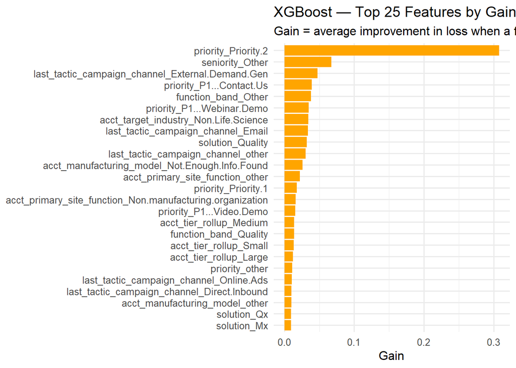

```r
# Feature importance
xgb_imp <- xgb.importance(
  feature_names = colnames(X_train),
  model         = xgb_fit
)

xgb_imp %>%
  slice_head(n = 25) %>%
  ggplot(aes(x = reorder(Feature, Gain), y = Gain)) +
  geom_col(fill = "orange") +
  coord_flip() +
  labs(
    title    = "XGBoost — Top 25 Features by Gain",
    subtitle = "Gain = average improvement in loss when a feature is used to split",
    x = NULL,
    y = "Gain"
  )
```

# 8. Model 3 — Random Forest

Random Forest is stable and handles lots of variables well

```r
# Fit (500 trees, default mtry = sqrt(p))
train_baked[is.na(train_baked)] <- 0


set.seed(42)
rf_fit <- randomForest(
  progressed ~ .,
  data       = train_baked,
  ntree      = 500,
  importance = TRUE,
  classwt    = c("No" = 1, "Yes" = 4)
)

print(rf_fit)
```

```
##
## Call:
##  randomForest(formula = progressed ~ ., data = train_baked, ntree = 500,      importance = TRUE, classwt = c(No = 1, Yes = 4))
##                Type of random forest: classification
##                      Number of trees: 500
## No. of variables tried at each split: 8
##
##         OOB estimate of  error rate: 17.27%
## Confusion matrix:
##       No  Yes class.error
## No  8601  958   0.1002197
## Yes 1054 1037   0.5040650
```

```r
# Predict & evaluate
rf_prob  <- predict(rf_fit, newdata = test_baked, type = "prob")[, "Yes"]
rf_class <- predict(rf_fit, newdata = test_baked, type = "class")

cm_rf <- confusionMatrix(rf_class, test_baked$progressed, positive = "Yes")
print(cm_rf)
```

```
## Confusion Matrix and Statistics
##
##           Reference
## Prediction   No  Yes
##        No  3669  474
##        Yes  393  419
##
##                Accuracy : 0.825
##                  95% CI : (0.8142, 0.8355)
##     No Information Rate : 0.8198
##     P-Value [Acc > NIR] : 0.173085
##
##                   Kappa : 0.3861
##
##  Mcnemar's Test P-Value : 0.006589
##
##             Sensitivity : 0.46920
##             Specificity : 0.90325
##          Pos Pred Value : 0.51601
##          Neg Pred Value : 0.88559
##              Prevalence : 0.18022
##          Detection Rate : 0.08456
##    Detection Prevalence : 0.16387
##       Balanced Accuracy : 0.68623
##
##        'Positive' Class : Yes
##
```

```r
roc_rf <- roc(
  response  = test_baked$progressed,
  predictor = rf_prob,
  levels    = c("No", "Yes")
)
cat(sprintf("\nRandom Forest AUC: %.4f\n", auc(roc_rf)))
```

```
##
## Random Forest AUC: 0.8199
```

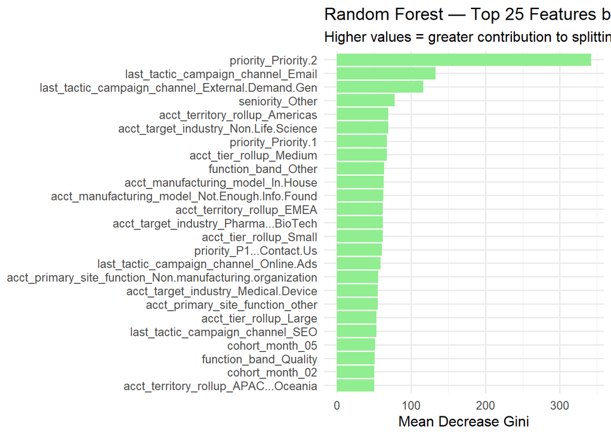

```r
rf_imp_df <- data.frame(
  Feature   = rownames(importance(rf_fit)),
  MeanDecreaseGini = importance(rf_fit)[, "MeanDecreaseGini"]
) %>%
  arrange(desc(MeanDecreaseGini)) %>%
  slice_head(n = 25)

ggplot(rf_imp_df, aes(x = reorder(Feature, MeanDecreaseGini),
                      y = MeanDecreaseGini)) +
  geom_col(fill = "lightgreen") +
  coord_flip() +
  labs(
    title    = "Random Forest — Top 25 Features by Mean Decrease in Gini",
    subtitle = "Higher values = greater contribution to splitting purity",
    x = NULL,
    y = "Mean Decrease Gini"
  )
```

# 9. Model Comparison & ROC Curves

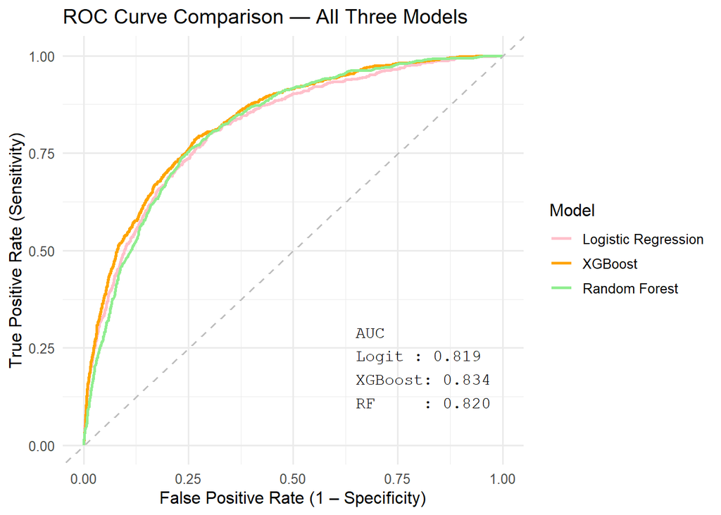

```r
# Overlay all three ROC curves
ggroc(
  list(
    "Logistic Regression" = roc_logit,
    "XGBoost"             = roc_xgb,
    "Random Forest"       = roc_rf
  ),
  legacy.axes = TRUE,
  size = 1
) +
  geom_abline(slope = 1, intercept = 0, linetype = "dashed",
              colour = "grey") +
  scale_colour_manual(
    values = c(
      "Logistic Regression" = "pink",
      "XGBoost"             = "orange",
      "Random Forest"       = "lightgreen"
    )
  ) +
  annotate("text", x = 0.65, y = 0.20,
           label = sprintf(
             "AUC\nLogit : %.3f\nXGBoost: %.3f\nRF     : %.3f",
             auc(roc_logit), auc(roc_xgb), auc(roc_rf)
           ),
           hjust = 0, size = 4, family = "mono") +
  labs(
    title   = "ROC Curve Comparison — All Three Models",
    x       = "False Positive Rate (1 – Specificity)",
    y       = "True Positive Rate (Sensitivity)",
    colour  = "Model"
  )
```

```r
# Side-by-side performance table
extract_metrics <- function(cm, roc_obj, model_name) {
  data.frame(
    Model      = model_name,
    AUC        = round(as.numeric(auc(roc_obj)), 4),
    Accuracy   = round(cm$overall["Accuracy"], 4),
    Precision  = round(cm$byClass["Precision"], 4),
    Recall     = round(cm$byClass["Recall"], 4),
    F1         = round(cm$byClass["F1"], 4),
    Specificity = round(cm$byClass["Specificity"], 4)
  )
}

metrics_df <- bind_rows(
  extract_metrics(cm_logit, roc_logit, "Logistic Regression"),
  extract_metrics(cm_xgb,   roc_xgb,   "XGBoost"),
  extract_metrics(cm_rf,    roc_rf,    "Random Forest")
)

metrics_df %>%
  gt() %>%
  tab_header(title = "Model Performance Summary — Test Set") %>%
  fmt_number(columns = -Model, decimals = 4) %>%
  tab_style(
    style = list(cell_fill(color = "lightblue"),
                 cell_text(weight = "bold")),
    locations = cells_body(
      rows = AUC == max(AUC)
    )
  )
```

Model Performance Summary — Test Set

| Model | AUC | Accuracy | Precision | Recall | F1 | Specificity |
| --- | --- | --- | --- | --- | --- | --- |
| Logistic Regression | 0.8189 | 0.8454 | 0.6545 | 0.3012 | 0.4126 | 0.9650 |
| XGBoost | 0.8343 | 0.8486 | 0.6636 | 0.3188 | 0.4307 | 0.9646 |
| Random Forest | 0.8199 | 0.8250 | 0.5160 | 0.4692 | 0.4915 | 0.9032 |

# 10. Calibration Plot (Best Model)

This checks how well predicted probabilities match reality. Can we trust the scores?

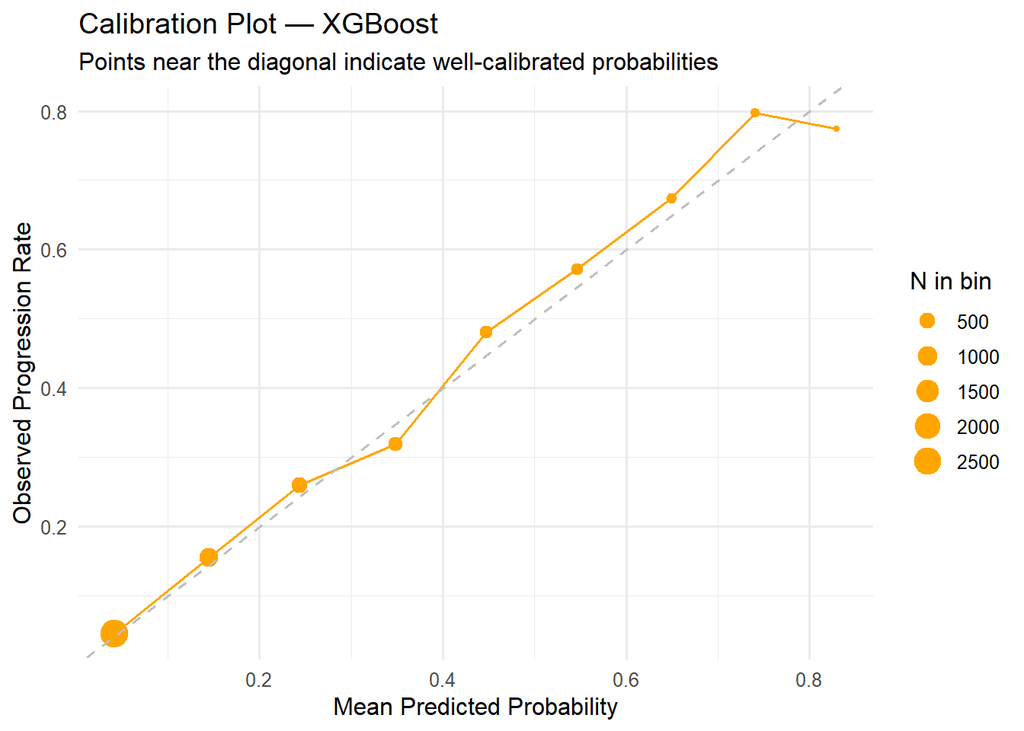

```r
# uses the best performing model
best_prob <- xgb_prob
best_actual <- y_test

cal_df <- data.frame(
  prob   = best_prob,
  actual = best_actual
) %>%
  mutate(bin = cut(prob, breaks = seq(0, 1, by = 0.1),
                   include.lowest = TRUE)) %>%
  group_by(bin) %>%
  summarise(
    mean_pred  = mean(prob),
    mean_actual = mean(actual),
    n          = n(),
    .groups    = "drop"
  )

ggplot(cal_df, aes(x = mean_pred, y = mean_actual)) +
  geom_point(aes(size = n), colour = "orange") +
  geom_line(colour = "orange") +
  geom_abline(slope = 1, intercept = 0, linetype = "dashed",
              colour = "grey") +
  scale_size_continuous(name = "N in bin") +
  labs(
    title    = "Calibration Plot — XGBoost",
    subtitle = "Points near the diagonal indicate well-calibrated probabilities",
    x = "Mean Predicted Probability",
    y = "Observed Progression Rate"
  )
```

# 11. Threshold Optimisation

The default 0.50 threshold maximizes accuracy. But for sales, we check

Lower threshold → catch more good leads (higher recall) Higher threshold → fewer false positives (higher precision)

We test different thresholds to find the best balance.

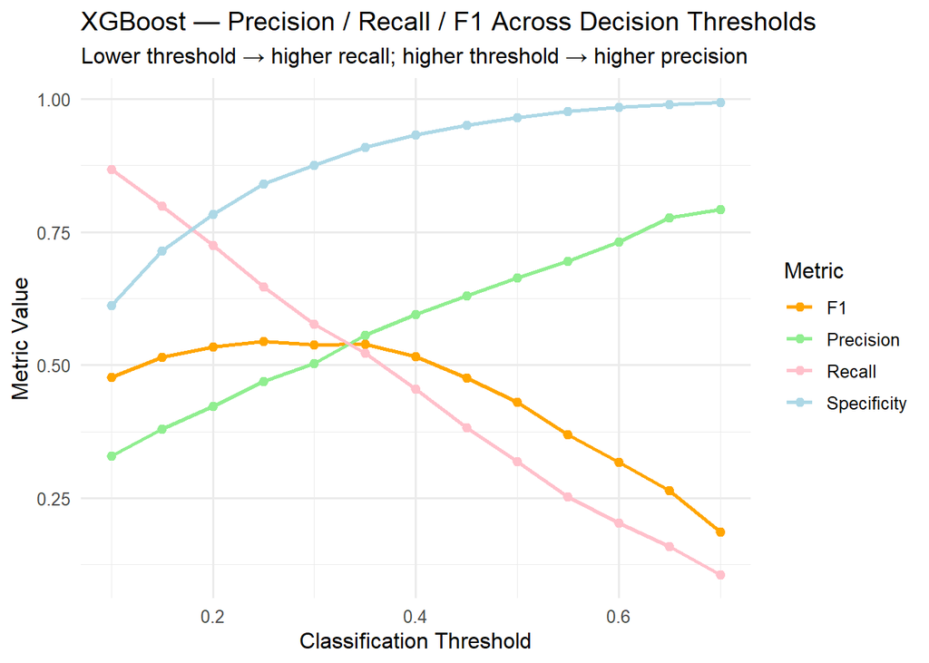

```r
# Precision-Recall tradeoff for XGBoost
thresholds <- seq(0.10, 0.70, by = 0.05)

thresh_df <- purrr::map_dfr(thresholds, function(t) {
  pred_class <- factor(if_else(xgb_prob >= t, "Yes", "No"),
                       levels = c("No", "Yes"))
  actual     <- factor(if_else(y_test == 1, "Yes", "No"),
                       levels = c("No", "Yes"))
  cm         <- confusionMatrix(pred_class, actual, positive = "Yes")
  data.frame(
    Threshold  = t,
    Precision  = cm$byClass["Precision"],
    Recall     = cm$byClass["Recall"],
    F1         = cm$byClass["F1"],
    Specificity = cm$byClass["Specificity"]
  )
})

thresh_long <- thresh_df %>%
  pivot_longer(-Threshold, names_to = "Metric", values_to = "Value")

ggplot(thresh_long, aes(x = Threshold, y = Value, colour = Metric)) +
  geom_line(size = 1) +
  geom_point(size = 2) +
  scale_colour_manual(values = c(
    Precision   = "lightgreen",
    Recall      = "pink",
    F1          = "orange",
    Specificity = "lightblue"
  )) +
  labs(
    title    = "XGBoost — Precision / Recall / F1 Across Decision Thresholds",
    subtitle = "Lower threshold → higher recall; higher threshold → higher precision",
    x = "Classification Threshold",
    y = "Metric Value",
    colour = "Metric"
  )
```

```r
# Highlight the F1-optimal threshold
best_thresh_row <- thresh_df %>%
  filter(!is.na(F1)) %>%
  slice_max(F1, n = 1)
cat(sprintf("F1-optimal threshold: %.2f  (Precision=%.3f, Recall=%.3f, F1=%.3f)\n",
            best_thresh_row$Threshold,
            best_thresh_row$Precision,
            best_thresh_row$Recall,
            best_thresh_row$F1))
```

```
## F1-optimal threshold: 0.25  (Precision=0.469, Recall=0.647, F1=0.544)
```

# 12. Lead Scoring & Actionable Segments

We use the best model to score every lead.

```r
# score the full dataset
full_baked <- bake(prepped, new_data = qal)
X_full     <- full_baked %>% select(-progressed) %>% as.matrix()

qal_scored <- qal %>%
  mutate(
    progression_score = predict(
      xgb_fit,
      xgb.DMatrix(data = X_full)
    ),
    score_tier = case_when(
      progression_score >= 0.40 ~ "Hot   (≥40%)",
      progression_score >= 0.25 ~ "Warm  (25–40%)",
      progression_score >= 0.15 ~ "Lukewarm (15–25%)",
      TRUE                      ~ "Cold  (<15%)"
    )
  )

qal_scored %>%
  count(score_tier) %>%
  mutate(pct = scales::percent(n / sum(n), accuracy = 0.1)) %>%
  gt() %>%
  tab_header(title = "Lead Score Distribution — Full Dataset")
```

Lead Score Distribution — Full Dataset

| score_tier | n | pct |
| --- | --- | --- |
| Cold (<15%) | 10223 | 61.4% |
| Hot (≥40%) | 2412 | 14.5% |
| Lukewarm (15–25%) | 2123 | 12.8% |
| Warm (25–40%) | 1886 | 11.3% |

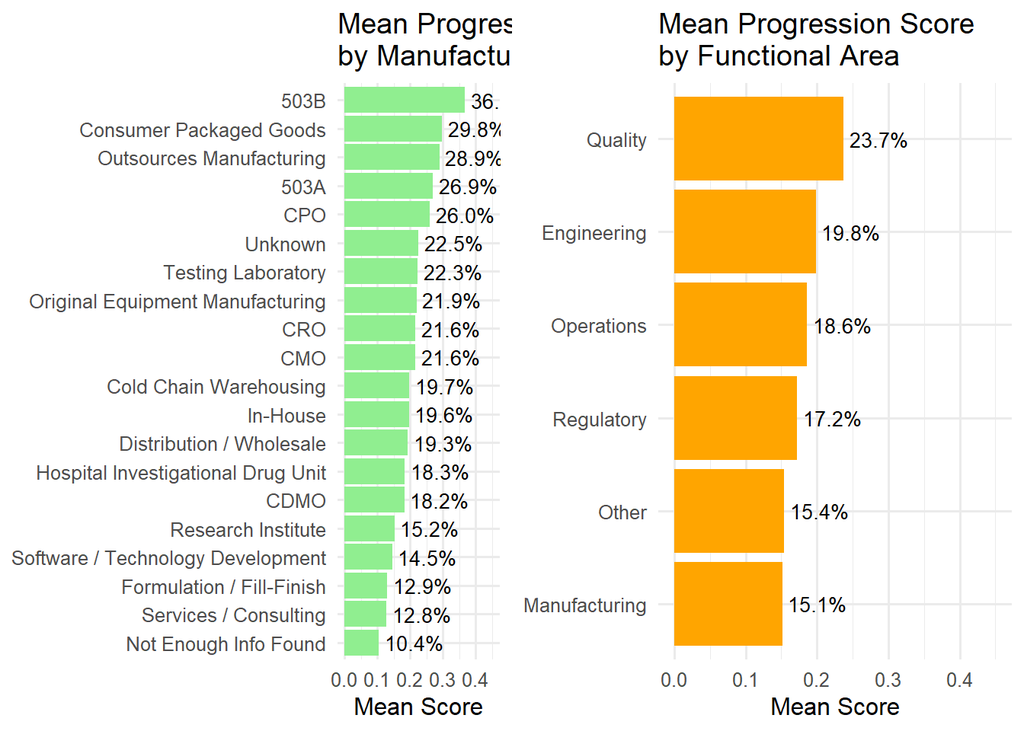

```r
# Mean score by key segments
seg_mfg <- qal_scored %>%
  group_by(acct_manufacturing_model) %>%
  summarise(
    n             = n(),
    mean_score    = mean(progression_score),
    actual_rate   = mean(progressed == "Yes"),
    .groups = "drop"
  ) %>%
  arrange(desc(mean_score))

p1 <- ggplot(seg_mfg,
       aes(x = reorder(acct_manufacturing_model, mean_score),
           y = mean_score)) +
  geom_col(fill = "lightgreen") +
  geom_text(aes(label = scales::percent(mean_score, accuracy = 0.1)),
            hjust = -0.1, size = 3.5) +
  coord_flip() +
  scale_y_continuous(limits = c(0, 0.45)) +
  labs(title = "Mean Progression Score\nby Manufacturing Model",
       x = NULL, y = "Mean Score")

seg_func <- qal_scored %>%
  group_by(function_band) %>%
  summarise(
    n          = n(),
    mean_score = mean(progression_score),
    .groups    = "drop"
  ) %>%
  arrange(desc(mean_score))

p2 <- ggplot(seg_func,
       aes(x = reorder(function_band, mean_score),
           y = mean_score)) +
  geom_col(fill = "orange") +
  geom_text(aes(label = scales::percent(mean_score, accuracy = 0.1)),
            hjust = -0.1, size = 3.5) +
  coord_flip() +
  scale_y_continuous(limits = c(0, 0.45)) +
  labs(title = "Mean Progression Score\nby Functional Area",
       x = NULL, y = "Mean Score")

grid.arrange(p1, p2, ncol = 2)
```

```r
# ICP Cluster Table
qal_scored %>%
  filter(solution_rollup == "Mx") %>%
  group_by(acct_manufacturing_model, acct_tier_rollup, function_band) %>%
  summarise(
    n              = n(),
    mean_score     = round(mean(progression_score), 3),
    actual_rate    = round(mean(progressed == "Yes"), 3),
    .groups        = "drop"
  ) %>%
  filter(n >= 50) %>%
  arrange(desc(mean_score)) %>%
  slice_head(n = 20) %>%
  gt() %>%
  tab_header(
    title    = "Top Mx ICP Clusters — Manufacturing Model × Tier × Function",
    subtitle = "Ranked by mean predicted progression score (min. 50 leads)"
  ) %>%
  fmt_number(columns = c(mean_score, actual_rate), decimals = 3) %>%
  tab_style(
    style     = cell_fill(color = "lightblue"),
    locations = cells_body(rows = mean_score >= 0.30)
  )
```

Top Mx ICP Clusters — Manufacturing Model × Tier × Function

Ranked by mean predicted progression score (min. 50 leads)

| acct_manufacturing_model | acct_tier_rollup | function_band | n | mean_score | actual_rate |
| --- | --- | --- | --- | --- | --- |
| In-House | Small | Quality | 64 | 0.199 | 0.188 |
| In-House | Small | Other | 192 | 0.192 | 0.198 |
| CMO | Medium | Quality | 60 | 0.165 | 0.217 |
| CDMO | Medium | Other | 167 | 0.147 | 0.138 |
| In-House | Medium | Quality | 265 | 0.145 | 0.158 |
| In-House | Medium | Manufacturing | 175 | 0.143 | 0.137 |
| CMO | Medium | Other | 104 | 0.142 | 0.154 |
| In-House | Medium | Other | 542 | 0.141 | 0.155 |
| In-House | Medium | Engineering | 105 | 0.134 | 0.105 |
| CDMO | Medium | Quality | 95 | 0.113 | 0.105 |
| In-House | Medium | Operations | 83 | 0.097 | 0.084 |
| In-House | Large | Quality | 58 | 0.090 | 0.069 |
| Services / Consulting | Small | Other | 98 | 0.086 | 0.092 |
| Not Enough Info Found | Small | Other | 123 | 0.085 | 0.033 |
| Services / Consulting | Medium | Other | 123 | 0.076 | 0.049 |
| In-House | Large | Other | 156 | 0.063 | 0.071 |
| Not Enough Info Found | Medium | Other | 153 | 0.051 | 0.020 |
| Not Enough Info Found | Large | Other | 51 | 0.040 | 0.059 |

# 13. Mx vs Qx Progression Score Comparison

Qx leads generally have higher scores overall Mx still has strong opportunities, especially in high-scoring segments

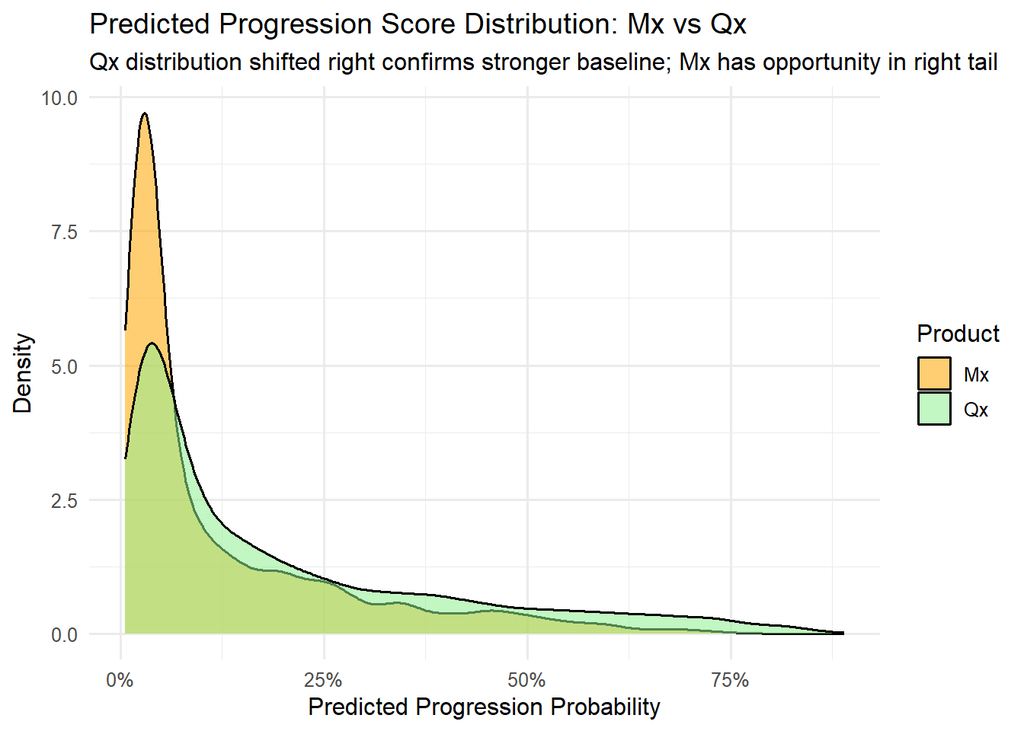

```r
qal_scored %>%
  filter(solution_rollup %in% c("Mx", "Qx")) %>%
  ggplot(aes(x = progression_score, fill = solution_rollup)) +
  geom_density(alpha = 0.55) +
  scale_fill_manual(values = c("Mx" = "orange", "Qx" = "lightgreen")) +
  scale_x_continuous(labels = scales::percent) +
  labs(
    title    = "Predicted Progression Score Distribution: Mx vs Qx",
    subtitle = "Qx distribution shifted right confirms stronger baseline; Mx has opportunity in right tail",
    x        = "Predicted Progression Probability",
    y        = "Density",
    fill     = "Product"
  )
```

# Mx Targeting Strategy

```r
# Create actionable Mx targeting strategy based on model results

# Analyze Mx segments by key characteristics
mx_segments <- qal_scored %>%
  filter(solution_rollup == "Mx") %>%
  group_by(acct_manufacturing_model, acct_tier_rollup) %>%
  summarise(
    n_leads = n(),
    avg_score = mean(progression_score),
    actual_rate = mean(progressed == "Yes"),
    .groups = "drop"
  ) %>%
  filter(n_leads >= 30) %>%  # Minimum sample size
  arrange(desc(avg_score))

# Show top and bottom segments
cat("=== MX TARGETING PLAYBOOK ===\n\n")
```

```
## === MX TARGETING PLAYBOOK ===
```

```r
cat("HIGH-PRIORITY MX SEGMENTS (Target These):\n")
```

```
## HIGH-PRIORITY MX SEGMENTS (Target These):
```

```r
top_5 <- mx_segments %>%
  slice_head(n = 5) %>%
  mutate(
    avg_score = scales::percent(avg_score, accuracy = 0.1),
    actual_rate = scales::percent(actual_rate, accuracy = 0.1)
  )

print(as.data.frame(top_5), row.names = FALSE)
```

```
##          acct_manufacturing_model acct_tier_rollup n_leads avg_score
##                               CMO            Small      62     23.9%
##  Original Equipment Manufacturing           Medium      85     20.3%
##                          In-House            Small     347     19.0%
##                              CDMO            Small      75     18.3%
##                               CMO           Medium     234     14.2%
##  actual_rate
##        27.4%
##        23.5%
##        18.7%
##        26.7%
##        17.1%
```

```r
cat("\n\nLOW-PRIORITY MX SEGMENTS (Avoid These):\n")
```

```
##
##
## LOW-PRIORITY MX SEGMENTS (Avoid These):
```

```r
bottom_5 <- mx_segments %>%
  slice_tail(n = 5) %>%
  mutate(
    avg_score = scales::percent(avg_score, accuracy = 0.1),
    actual_rate = scales::percent(actual_rate, accuracy = 0.1)
  )

print(as.data.frame(bottom_5), row.names = FALSE)
```

```
##           acct_manufacturing_model acct_tier_rollup n_leads avg_score
##                 Research Institute           Medium      32      6.8%
##  Software / Technology Development           Medium      51      6.7%
##              Not Enough Info Found           Medium     230      6.6%
##              Services / Consulting            Large      47      5.7%
##              Not Enough Info Found            Large      85      5.0%
##  actual_rate
##         3.1%
##         7.8%
##         3.9%
##         4.3%
##         8.2%
```

```r
# Calculate improvement potential
high_priority <- qal_scored %>%
  filter(solution_rollup == "Mx",
         progression_score >= 0.18)  # Above baseline threshold

all_mx <- qal_scored %>%
  filter(solution_rollup == "Mx")

cat("\n\n=== EXPECTED IMPACT ===\n")
```

```
##
##
## === EXPECTED IMPACT ===
```

```r
cat("Current Mx baseline:", scales::percent(mean(all_mx$progression_score), accuracy = 0.1), "\n")
```

```
## Current Mx baseline: 12.4%
```

```r
cat("High-priority segments (>18% predicted):",
    scales::percent(mean(high_priority$progression_score), accuracy = 0.1), "\n")
```

```
## High-priority segments (>18% predicted): 34.6%
```

```r
cat("Number of high-priority leads:", nrow(high_priority),
    "out of", nrow(all_mx),
    paste0("(", round(100*nrow(high_priority)/nrow(all_mx), 1), "%)"), "\n")
```

```
## Number of high-priority leads: 1025 out of 4178 (24.5%)
```

```r
cat("Improvement potential: +",
    round((mean(high_priority$progression_score) - mean(all_mx$progression_score)) * 100, 1),
    "percentage points\n")
```

```
## Improvement potential: + 22.2 percentage points
```

Mx Targeting Strategy:

Clear losers: Services, Software, Research companies (<7% predicted) - not actual manufacturers.

For SDRs: Target CMO/CDMO + Small and In-House + Small. Avoid Services/Software segments.

# 14. Key Findings & Actionable Recommendations

This modeling helped to uncover lead progression using prediction on the available data. Out of the different models explored, XGBoost performed the best. logistic regression helped with the interpretation.

#AI LOG AI was used to help formulate and debug coding, especially for the figures used. Some help was sought confirming output interpretation